# Modelling workshop: Session 5

## Session 5

**Session 5** contains an introduction to Luminex and other serology data from a ‘data analyses’ perspective and how we can use models to estimate things such as *seropositive* versus *seronegative* results by finding cut offs and using ROC curves.

### Session 5a - antibody titres as data

The first thing to remember is that the antibodies that were measured are populations of immunoglobulins. That means that they have properties similar to other things that we count and measure.

The second thing to remember is that antibody populations are dynamic and changing through time.

Let’s now import our recently created and saved data set, **example_data.csv** and begin:

```r
library(tidyverse)
example_data <- read.csv("data/example_data.csv")
glimpse(example_data)
```

```
## Rows: 51
## Columns: 24
## $ Patient                            <int> 639064, 639220, 639265, 639301, 639…
## $ Cohort                             <chr> "mild", "mild", "mild", "mild", "mi…
## $ Clinical.features                  <chr> "-", "-", "-", "-", "-", "-", "-", …
## $ Date.of.birth                      <chr> "1943-03-15", "1934-01-24", "1981-1…
## $ Age                                <int> 77, 86, 39, 15, 0, 90, 62, 16, 34, …
## $ Sex                                <chr> "M", "M", "F", "F", "M", "F", "M", …
## $ Date.of.symptoms                   <chr> "2020-03-10", NA, "2020-03-27", "20…
## $ Date.of.PCR.test                   <chr> "2020-03-11", "2020-03-24", "2020-0…
## $ Date.of.blood.sample               <chr> "2020-04-15", "2020-04-20", "2020-0…
## $ Time.from.PCR.to.blood.sample      <int> 35, 27, 25, 15, 2, 8, 16, 15, 18, 2…
## $ Time.from.symptoms.to.blood.sample <int> 36, NA, 26, 16, 3, 9, 16, NA, 19, 3…
## $ IgG.Beckman                        <dbl> 0.21, 51.07, 8.84, 15.57, 1.81, 30.…
## $ Result.Beckman                     <chr> "NEG", "POS", "POS", "POS", "POS", …
## $ Total.Ab.Roche                     <dbl> 0.082, 86.660, 21.910, 5.440, 21.17…
## $ Result.Roche                       <chr> "NEG", "POS", "POS", "POS", "POS", …
## $ IgG_S                              <dbl> 2.023055, 56.576121, 21.959659, 59.…
## $ IgG_E                              <dbl> 1.1436107, 1.1660746, 1.2281292, 1.…
## $ IgG_M                              <dbl> 1.1493747, 3.5215789, 1.5202583, 1.…
## $ IgM_S                              <dbl> 1.144476, 24.310832, 5.159334, 8.26…
## $ IgM_E                              <dbl> 1.017370, 1.268121, 1.292214, 1.361…
## $ IgM_M                              <dbl> 1.1125156, 2.6435373, 1.6662231, 1.…
## $ IgA_S                              <dbl> 1.148983, 13.988333, 6.302265, 4.41…
## $ IgA_E                              <dbl> 1.0827552, 1.0315657, 1.0192143, 1.…
## $ IgA_M                              <dbl> 1.2171865, 2.3856531, 1.5634358, 1.…
```

Remember that R has again imported the data and made the text as *character* data types when we want some as *dates* and some as *factors*. Let’s change those:

```r
example_data <- example_data %>%
  mutate_at(vars("Cohort", "Sex", "Result.Beckman", "Result.Roche"), as.factor)
example_data <- example_data %>%
  mutate_at(vars("Date.of.birth","Date.of.symptoms","Date.of.PCR.test","Date.of.blood.sample"), ~ as.Date(., format = "%Y-%m-%d"))

glimpse(example_data)
```

```
## Rows: 51
## Columns: 24
## $ Patient                            <int> 639064, 639220, 639265, 639301, 639…
## $ Cohort                             <fct> mild, mild, mild, mild, mild, mild,…
## $ Clinical.features                  <chr> "-", "-", "-", "-", "-", "-", "-", …
## $ Date.of.birth                      <date> 1943-03-15, 1934-01-24, 1981-10-17…
## $ Age                                <int> 77, 86, 39, 15, 0, 90, 62, 16, 34, …
## $ Sex                                <fct> M, M, F, F, M, F, M, F, F, F, F, F,…
## $ Date.of.symptoms                   <date> 2020-03-10, NA, 2020-03-27, 2020-0…
## $ Date.of.PCR.test                   <date> 2020-03-11, 2020-03-24, 2020-03-28…
## $ Date.of.blood.sample               <date> 2020-04-15, 2020-04-20, 2020-04-22…
## $ Time.from.PCR.to.blood.sample      <int> 35, 27, 25, 15, 2, 8, 16, 15, 18, 2…
## $ Time.from.symptoms.to.blood.sample <int> 36, NA, 26, 16, 3, 9, 16, NA, 19, 3…
## $ IgG.Beckman                        <dbl> 0.21, 51.07, 8.84, 15.57, 1.81, 30.…
## $ Result.Beckman                     <fct> NEG, POS, POS, POS, POS, POS, POS, …
## $ Total.Ab.Roche                     <dbl> 0.082, 86.660, 21.910, 5.440, 21.17…
## $ Result.Roche                       <fct> NEG, POS, POS, POS, POS, POS, POS, …
## $ IgG_S                              <dbl> 2.023055, 56.576121, 21.959659, 59.…
## $ IgG_E                              <dbl> 1.1436107, 1.1660746, 1.2281292, 1.…
## $ IgG_M                              <dbl> 1.1493747, 3.5215789, 1.5202583, 1.…
## $ IgM_S                              <dbl> 1.144476, 24.310832, 5.159334, 8.26…
## $ IgM_E                              <dbl> 1.017370, 1.268121, 1.292214, 1.361…
## $ IgM_M                              <dbl> 1.1125156, 2.6435373, 1.6662231, 1.…
## $ IgA_S                              <dbl> 1.148983, 13.988333, 6.302265, 4.41…
## $ IgA_E                              <dbl> 1.0827552, 1.0315657, 1.0192143, 1.…
## $ IgA_M                              <dbl> 1.2171865, 2.3856531, 1.5634358, 1.…
```

Note we had to change the **as.Date()** format to *“%Y-%m-%d”*

Now let’s think about the *antibody titres* data; let’s choose *IgG_S* as an example data set.

```r
print(example_data$IgG_S)
```

```
##  [1]   2.023055  56.576121  21.959659  59.752672  25.800880  62.584791
##  [7]  90.678211   1.885652  52.048696   3.918395  12.072658  44.397794
## [13]   4.066433   1.430782  57.306616   1.545768  11.943333   8.291773
## [19]  13.437330   3.370501  10.294082  12.625157  75.933302  10.287781
## [25]  37.291811  11.247528  49.293705  42.797368 129.957543   8.743495
## [31]  34.328837  24.955527  41.589412  18.210300   1.098789  37.475024
## [37]  29.686072  21.770875  27.030984  28.102601  21.905439  23.613221
## [43]  34.478671  20.708948  60.320493 156.733490  43.863906  73.212860
## [49]  46.512940  28.519854  64.438292
```

This is continuous numeric data, so let’s do some basic statistics on these:

```r
summary(example_data$IgG_S)
```

```
##    Min. 1st Qu.  Median    Mean 3rd Qu.    Max.
##   1.099  11.595  27.031  34.551  47.903 156.733
```

This tells us that the *minimum* (Min.) is 1.099, *first quartile* (1st Qu.) 11.595, *median* (Median) 27.031, *mean* (Mean) 34.551, *third quartile* (3rd Qu.) 47.903 and *maximum* (Max.) 156.733.

We can summarize that using another function, **boxplot.stats()**:

```r
boxplot.stats(example_data$IgG_S, do.conf = FALSE)
```

```
## $stats
## [1]  1.098789 11.595431 27.030984 47.903322 90.678211
##
## $n
## [1] 51
##
## $conf
## NULL
##
## $out
## [1] 129.9575 156.7335
```

Which also tells us the sample size (n=51) and that there are some **outliers** ($out). These may or may not be important.

Now lets plot that in several ways. In the *base* plot it looks like this:

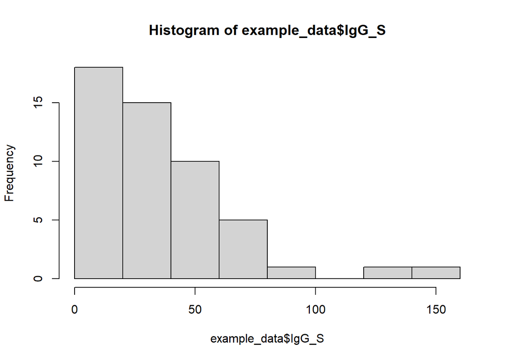

```r
hist(example_data$IgG_S)
```

We have seen this before, but let’s look at the data more.

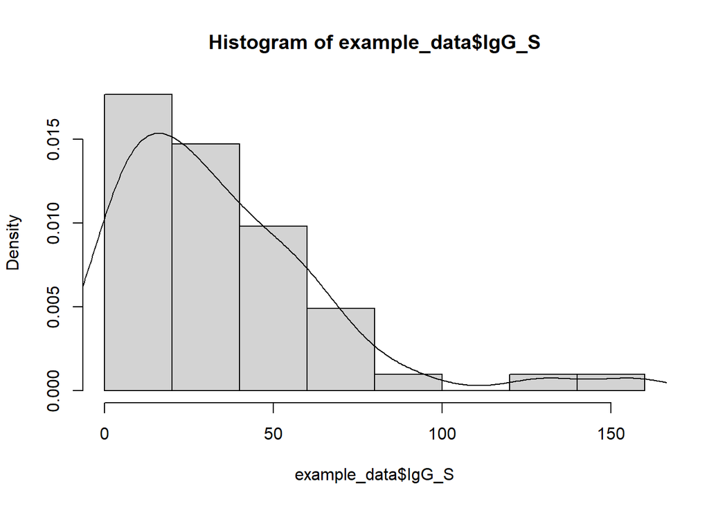

```r
hist(example_data$IgG_S, freq = FALSE)
lines(density(example_data$IgG_S))
```

In the *tidyverse* plot the histogram looks like:

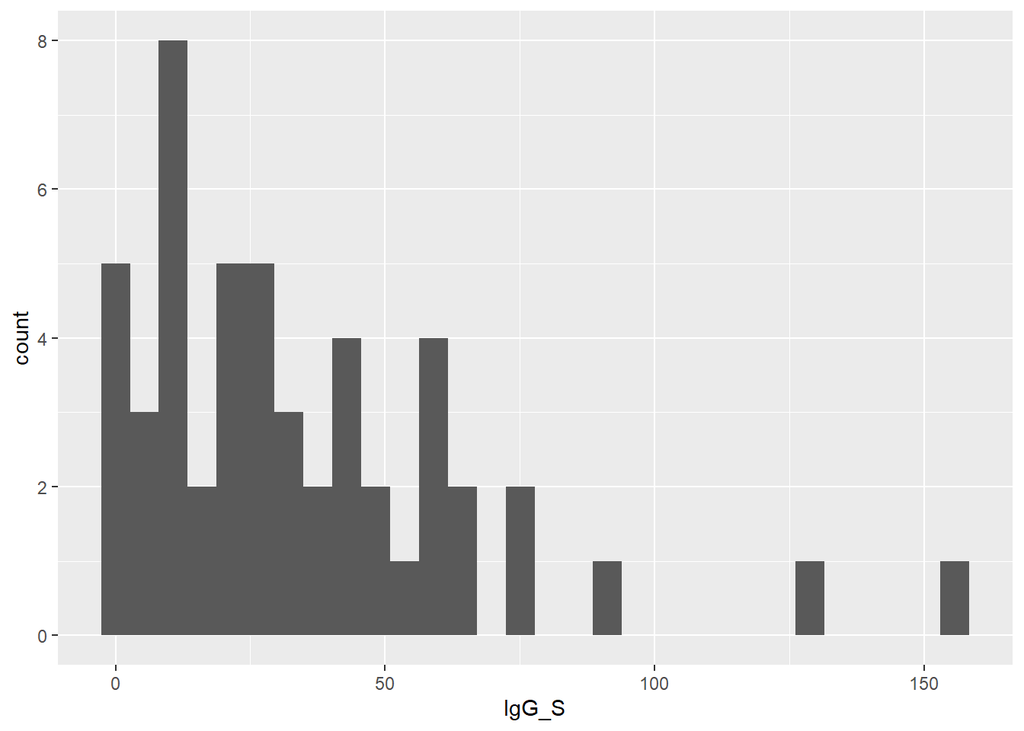

```r
ggplot(example_data, aes(x=IgG_S)) +
  geom_histogram()
```

Note that these data are **skewed data**.

Skewed refers to a type of **data distribution** where the values are not evenly distributed around the *mean*.

In a *normal distribution*, the values are distributed *symmetrically* around the mean, with an equal number of observations above and below the mean. However, in a skewed distribution, the data is pulled towards one tail, resulting in a longer tail on one side of the distribution than the other.

There are two types of skewness: **positive skewness** and **negative skewness**. Positive skewness occurs when the tail of the distribution is longer on the *right-hand side* of the distribution, like the *IgG_S* data, while negative skewness occurs when the tail of the distribution is longer on the left-hand side of the distribution. Skewed data can occur for various reasons, such as outliers, data transformation, or natural variation in the data.

It’s important to be aware of skewness in data because it can affect statistical analyses and modeling. For example, if the data is positively skewed, the mean may not be a representative measure of *central tendency*, and using **parametric tests** that *assume normality* may not be appropriate. In such cases, **non-parametric** methods may be more suitable for analysis.

**Note that for us the highest results might be interesting - these might be the serologically positive results!**

How can we work out what is and is not positive?

Let’s plot some of the other *anti-spike antibody* data. We will use a different technique to what we did previously and just trying overlaying the different data:

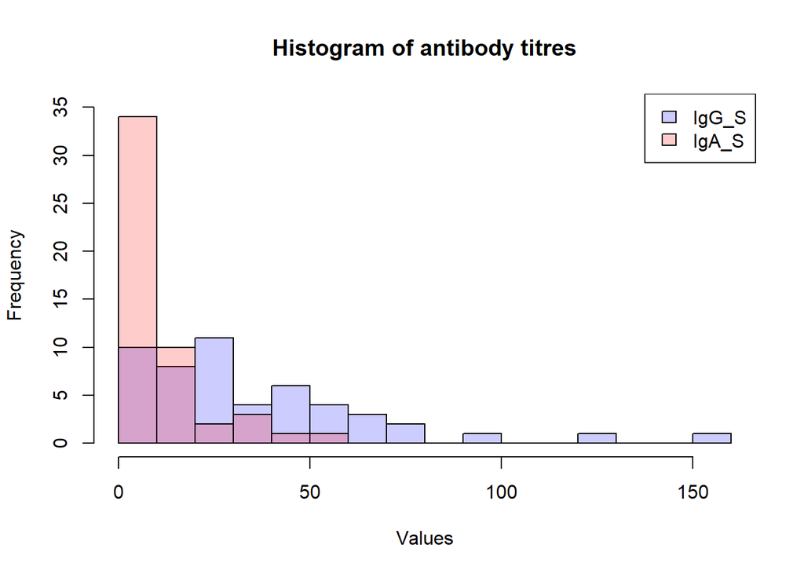

```r
#plot two histograms in same graph
hist(example_data$IgG_S,
     col=rgb(0,0,1,0.2),
     breaks = 20,
     ylim = c(0,35),
     xlab='Values', ylab='Frequency', main='Histogram of antibody titres')
hist(example_data$IgA_S,
     #breaks = 50,
     col=rgb(1,0,0,0.2),
     add=TRUE)

#add legend
legend('topright', c('IgG_S', 'IgA_S'),
       fill=c(rgb(0,0,1,0.2), rgb(1,0,0,0.2)))
```

We can see the *IgA_S* has more low values and the *IgG_S* has higher values. This is not unexpected, given what we know about antibody titres and the immune system.

#### 5b - Cut offs, ROC, and test characteristics

However, let’s *imagine* that these are *antibodies against different viruses*, so imagine that these are both *IgG* but against different viruses. How can we know if these are different?

Let’s make these into the *long format* data again:

```r
library(tidyr)
# Select columns to keep and gather
cols_to_keep <- c("Patient")
cols_to_gather <- c("IgG_S", "IgA_S")
# Gather columns and create new data set
long_data <- example_data %>%
  gather(key = "Antibody", value = "Titre", one_of(cols_to_gather)) %>%
  select(cols_to_keep, Antibody, Titre) %>%
  mutate(Antibody = factor(Antibody)) # Note without this, Antibody would be a character
glimpse(long_data)
```

```
## Rows: 102
## Columns: 3
## $ Patient  <int> 639064, 639220, 639265, 639301, 639306, 639311, 639329, 63934…
## $ Antibody <fct> IgG_S, IgG_S, IgG_S, IgG_S, IgG_S, IgG_S, IgG_S, IgG_S, IgG_S…
## $ Titre    <dbl> 2.023055, 56.576121, 21.959659, 59.752672, 25.800880, 62.5847…
```

Now let’s plot them in ggplot:

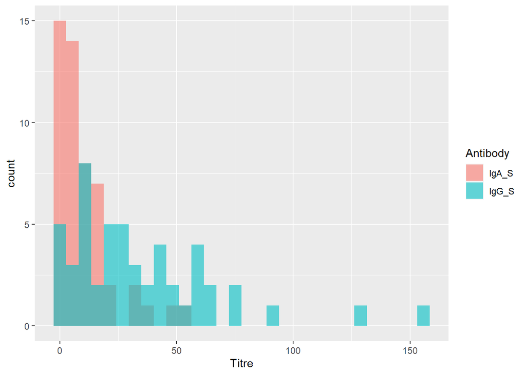

```r
library(ggplot2)
ggplot(long_data, aes(x=Titre, fill=Antibody)) + geom_histogram(alpha=0.6, position="identity")
```

They look different; let’s plot these as box plots and overlay the data:

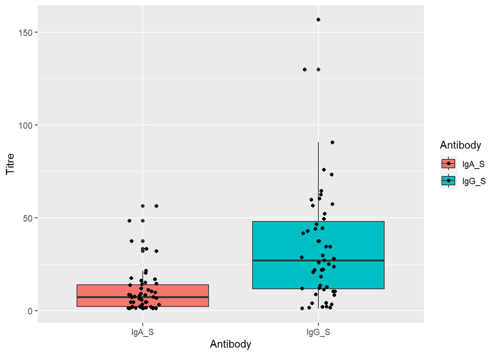

```r
ggplot(long_data, aes(x=Antibody, y=Titre, fill=Antibody)) +
  geom_boxplot() + geom_jitter(width = 0.1)
```

Or even fancier, using a **violin** plot:

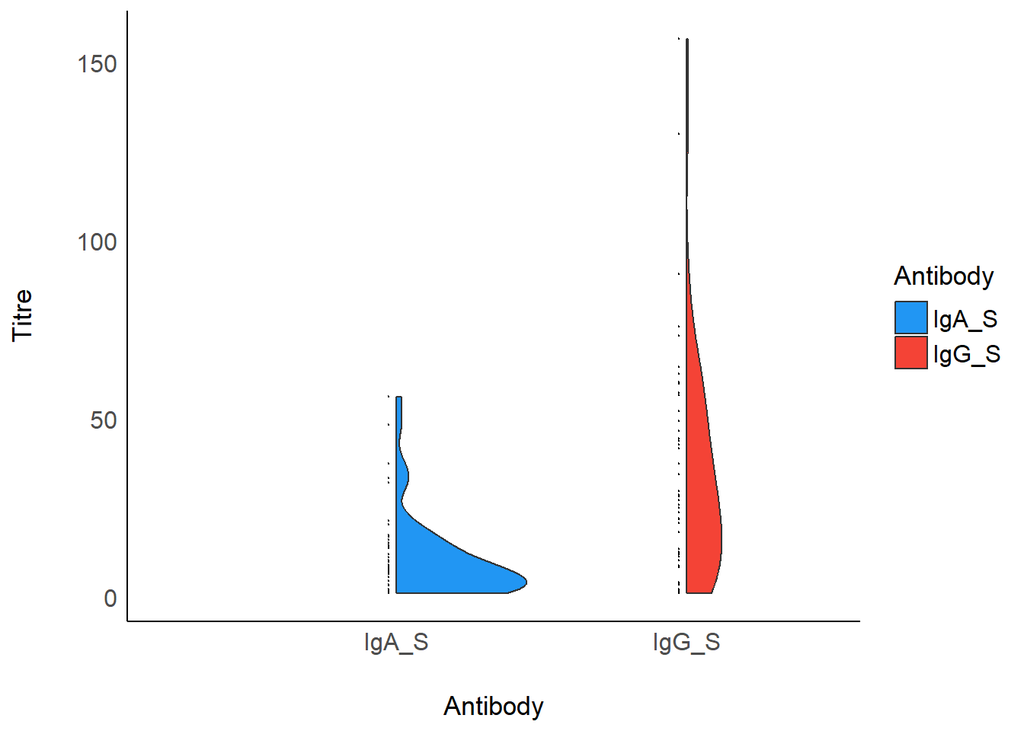

```r
library(ggplot2)
library(see)
ggplot(long_data, aes(x = Antibody, y = Titre, fill = Antibody)) +
  geom_violindot(fill_dots = "black") +
  theme_modern() +
  scale_fill_material_d()
```

We can test if there is statistical support for these coming from different distributions using a test called the **Kolmogorov-Smirnov Test**. This test is a *non-parametric* test and does not assume the data are from a *normal* distribution:

```r
ks.test(example_data$IgA_S, example_data$IgG_S)
```

```
##
##  Exact two-sample Kolmogorov-Smirnov test
##
## data:  example_data$IgA_S and example_data$IgG_S
## D = 0.52941, p-value = 6.849e-07
## alternative hypothesis: two-sided
```

And we can plot this in another way:

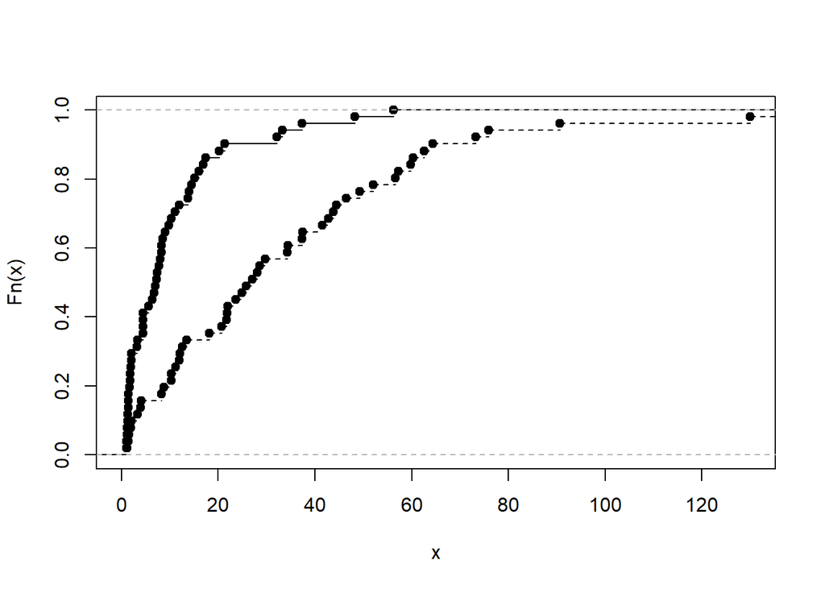

```r
plot(ecdf(example_data$IgA_S), main = "", xlim=c(0,130))
plot(ecdf(example_data$IgG_S), add = TRUE, lty = "dashed")
```

The **ks.test()** function performs a two-sample Kolmogorov-Smirnov test to compare the distributions of the data sets and the **p-value** is a measure of the evidence against the null hypothesis that the two datasets are drawn from the same distribution.

Here the p-value is very low, so there is good support that they are different. If the p-value is greater than **the significance level** (usually 0.05), we fail to reject the null hypothesis and conclude that there is not enough evidence to suggest that the datasets are from different distributions.

We can simulate some data from the same distributions to show what that would look like:

```r
# Set seed for reproducibility
set.seed(123)

# Simulate first Poisson dataset
lambda <- 30
n <- 100
data1 <- rpois(n, lambda)

# Simulate second Poisson dataset
data2 <- rpois(n, lambda)

# Test if datasets are from the same distribution using ks.test
ks.test(data1, data2)
```

```
##
##  Asymptotic two-sample Kolmogorov-Smirnov test
##
## data:  data1 and data2
## D = 0.07, p-value = 0.9671
## alternative hypothesis: two-sided
```

And then let’s plot those the same way:

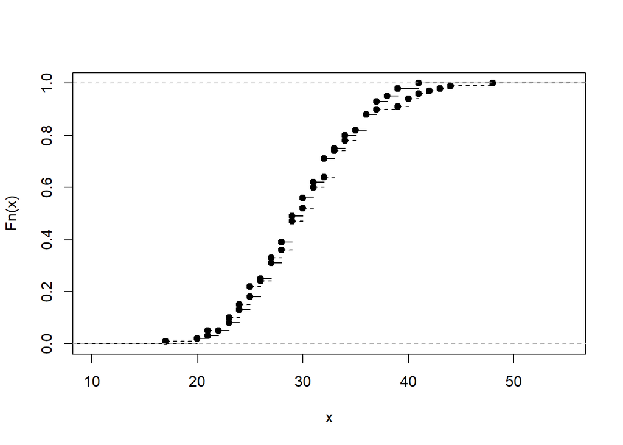

```r
plot(ecdf(data1), main = "", xlim=c(10,55))
plot(ecdf(data2), add = TRUE, lty = "dashed")
```

Now let’s imagine that these antibody titres are from the same population but the *IgA_S* class with the lower titres are from **naive** animals that have never has an infection (so susceptible in the modelling), and that the *IgG_S* are the **immune** or if not immune **recovered** animals (recovered) that are truly **seropositive**, but we want to find the difference.

You can see that some of the *“negative”* animals have titres that are equal or higher than the *“positive”* animals. This is not uncommon. Many things determine this, such as previous infections with related infections or waning antibody titres. These lead to **false positive** and **false negative** results.

##### Test sensitivity and specificity and predictive values

**Sensitivity** and **specificity** are two measures used to evaluate the performance of any test that has this *binary* classification model, which we often want.

**Sensitivity** is the proportion of **true positive cases** that are correctly identified by the model. It measures how well the model can identify the individuals who actually have the condition, out of all individuals who do have the condition. A model with high sensitivity correctly identifies most of the true positive cases and has a low false negative rate.

**Specificity** is the proportion of true negative cases that are correctly identified

We can quickly look at this using some simple maths and then a piece of code. Here we use some exmaple data showing whether an animal is diseased or not and if it tested positive by a diagnostic test.

|  | Disease | No Disease |
| --- | --- | --- |
| Positive | 75 | 10 |
| Negative | 25 | 90 |

We can calculate the **sensitivity** and **specificity** by:

*Sensitivity* = $\frac{TP}{TP + FN}$ = $\frac{75}{75 + 25}$ = 0.75

*Specificity* = $\frac{TN}{TN + FP}$ = $\frac{90}{90 + 10}$ = 0.9

The next example is lifted directly from the **epiR** package. It generates a data set listing test results (called *tes*) and true disease status (called *dis*):

```r
library(epiR)
library(tidyverse)
dis <- c(rep(1, times = 744), rep(0, times = 842))
tes <- c(rep(1, times = 670), rep(0, times = 74),
rep(1, times = 202), rep(0, times = 640))
dat.df02 <- data.frame(dis, tes)
tmp.df02 <- dat.df02 %>%
mutate(dis = factor(dis, levels = c(1,0), labels = c("Dis+","Dis-"))) %>%
mutate(tes = factor(tes, levels = c(1,0), labels = c("Test+","Test-"))) %>%
group_by(tes, dis) %>%
summarise(n = n())
```

[output not shown]

```r
tmp.df02
```

```
## # A tibble: 4 × 3
## # Groups:   tes [2]
##   tes   dis       n
##   <fct> <fct> <int>
## 1 Test+ Dis+    670
## 2 Test+ Dis-    202
## 3 Test- Dis+     74
## 4 Test- Dis-    640
```

```r
## View the data in conventional 2 by 2 table format:
pivot_wider(tmp.df02, id_cols = c(tes), names_from = dis, values_from = n)
```

```
## # A tibble: 2 × 3
## # Groups:   tes [2]
##   tes   `Dis+` `Dis-`
##   <fct>  <int>  <int>
## 1 Test+    670    202
## 2 Test-     74    640
```

```r
rval.tes02 <- epi.tests(tmp.df02, method = "exact", digits = 2,
conf.level = 0.95)
summary(rval.tes02)
```

```
##    statistic         est       lower      upper
## 1         ap  0.54981084  0.52493735  0.5744996
## 2         tp  0.46910467  0.44430554  0.4940184
## 3         se  0.90053763  0.87674618  0.9210923
## 4         sp  0.76009501  0.72977646  0.7885803
## 5    diag.ac  0.82597730  0.80640489  0.8443346
## 6    diag.or 28.68611185 21.51819166 38.2417364
## 7       nndx  1.51370055  1.40910043  1.6487431
## 8     youden  0.66063265  0.60652264  0.7096726
## 9     pv.pos  0.76834862  0.73889263  0.7959784
## 10    pv.neg  0.89635854  0.87163929  0.9177402
## 11    lr.pos  3.75372618  3.32068844  4.2432346
## 12    lr.neg  0.13085517  0.10506432  0.1629771
## 13    p.rout  0.45018916  0.42550037  0.4750627
## 14     p.rin  0.54981084  0.52493735  0.5744996
## 15    p.tpdn  0.23990499  0.21141968  0.2702235
## 16    p.tndp  0.09946237  0.07890770  0.1232538
## 17    p.dntp  0.23165138  0.20402157  0.2611074
## 18    p.dptn  0.10364146  0.08225983  0.1283607
```

This provides a large amount of information on the tests and data.

The **apparent prevalence (ap)** is what the test results show. But the **true prevalence (tp)** accounts for the test specificity and sensitivity, where:

$$True\, Prevalence = \frac{Apparent\,
Prevalence + (Specificity − 1)}
{Specificity + (Sensitivity − 1)}$$

and where **se** in the results in the **diagnostic test sensitivity** and **sp** the **diagnostic test specificity**

There are several other metrics, but the only two others we will cover here are the **positive predictive value** (**pv.pos**) and **negative predictive value** (**pv.neg**) which are the ratios of cases truly diagnosed as positive to all those who had positive test results and negative to those who had positive test results.

Importantly, **positive predictive value** and **negative predictive value** are sensitive to the prevalence of infection. Run the above code again with altered values and you will see.

These sensitivity and specificity calculations **assume** that we know what the true result is. For example, in the **example_data** which test antibody results are the truth?